# ESKD risk estimation with 40% egfr decline for NA and MA group

Daniel Montemayor and Rabiul Islam Center for Renal Precision Medicine University of Texas Health San Antonio School of Medicine

2022-02-15

[figure not shown]

Center for Renal Precision Medicine

# 1 Brief

+Cumulative risk estimation with eGFR decline of 40% in each of the bins for the normo and micro groups + Partion by Adenine Tertiles for NA, MA groups. +Count the outcomes and cumulative ESKD risk with respect to years

```r
knitr::opts_chunk$set(message = FALSE, warning=FALSE)
```

```r
#Requirements
requirements <- c("dplyr","reshape","ggplot2","tidyverse","rstatix","ggpubr")

#CRAN repository
repos <- "http://cran.us.r-project.org"

#install and load missing requirements
for (pack in requirements){
  if( !is.element(pack, .packages(all.available = TRUE)) ) {
    #install.packages(pack, repos = repos)
    install.packages(pack)
  }
  library(pack, character.only = TRUE)
}
```

```r
rm(list=ls())
#Constants
MWade = 135.13 # molecular weights for adenine in g/mol
MWcre = 113.12 #molecular weights for creatinine in g/mol

#Random number seed
set.seed(10079)
```

```r
#get data
rawdata <- read.csv("RedCapUp2.csv")
```

```r
#remove patients with no adenine values
rawdata <- rawdata[!is.na(rawdata$Adenine..nM.uM.), ]
```

# 2 Display Adenine cutoff values between tertiles

```r
#get ACR in units of mg/mmol
rawdata$acr<-(rawdata$urine_albumin_v3y0/rawdata$urine_creatinine_v3y0)*1000/88.42

#select normogroup
normopats <- rawdata$acr <3
micropats <- rawdata$acr >=3 & rawdata$acr <30
print(paste("number of patients with normo-albuminuria = ", sum(normopats, na.rm = TRUE)))
```

```
## [1] "number of patients with normo-albuminuria =  293"
```

```r
print(paste("number of patients with micro-albuminuria = ", sum(micropats, na.rm = TRUE)))
```

```
## [1] "number of patients with micro-albuminuria =  260"
```

# 3 get adenine tertiles cutoff values

```r
quants <- quantile(rawdata$Adenine..nM.uM., c(0,1/3,2/3,1), na.rm = TRUE)
print(paste("tertile cutoffs in (nm/um)= ", paste(quants, collapse=", ")))
```

```
## [1] "tertile cutoffs in (nm/um)=  0, 0.004724269, 0.024688888, 3.992470467"
```

```r
print(paste("tertile cutoffs in (mg/g)= ", paste(quants*MWcre/MWade, collapse=", ")))
```

```
## [1] "tertile cutoffs in (mg/g)=  0, 0.00395477917028047, 0.0206675572453193, 3.34217612097269"
```

```r
T1pats <- rawdata$Adenine..nM.uM. >= quants[1] & rawdata$Adenine..nM.uM. < quants[2]
T2pats <- rawdata$Adenine..nM.uM. >= quants[2] & rawdata$Adenine..nM.uM. < quants[3]
T3pats <- rawdata$Adenine..nM.uM. >= quants[3]
print(paste("Total number of patients ", sum(!is.na(rawdata$Adenine..nM.uM.))))
```

```
## [1] "Total number of patients  952"
```

```r
print(paste("number of patients in T1 ", sum(T1pats, na.rm = TRUE)))
```

```
## [1] "number of patients in T1  317"
```

```r
print(paste("number of patients in T2 ", sum(T2pats, na.rm = TRUE)))
```

```
## [1] "number of patients in T2  317"
```

```r
print(paste("number of patients in T3 ", sum(T3pats, na.rm = TRUE)))
```

```
## [1] "number of patients in T3  318"
```

# 4 Normal Group: 40% eGFR decline at each year

```r
#print(paste("year", "T1events", "T2events", "T3events"))

#make a dataframe to hold event count
df <- data.frame(matrix(nrow=7, ncol = 4))
colnames(df) <- c("year", "T1", "T2", "T3")
#Count no. of false patients for each tertile
ptdf<-data.frame(matrix(nrow=7,ncol=4))
colnames(ptdf) <- c("year", "T1", "T2", "T3")
#select eGFR
EGFR<-rawdata%>%
   dplyr::select(egfr_cric_v5y1,egfr_cric_v7y2,egfr_cric_v9y3,egfr_cric_v11y4,egfr_cric_v13y5,egfr_cric_v15y6,egfr_cric_v17y7,egfr_cric_v19y8,egfr_cric_v21y9,egfr_cric_v23y10)
#loop over years and count events for each year
for (year in 1:7){
  #print(year)
  #calculate 40% decline at each year
  t1 <- EGFR[,year]
  t0 <- rawdata$egfr_cric_v3y0
  rawdata$outcome = ((t1-t0)/t0 < -.40)# | (t2==1)
  T1events <- sum(rawdata$outcome[T1pats & normopats], na.rm = TRUE)
  T1eventsF <- sum(!rawdata$outcome[T1pats & normopats], na.rm = TRUE)
  T2events <- sum(rawdata$outcome[T2pats & normopats], na.rm = TRUE)
  T2eventsF <- sum(!rawdata$outcome[T2pats & normopats], na.rm = TRUE)
  T3events <- sum(rawdata$outcome[T3pats & normopats], na.rm = TRUE)
  T3eventsF <- sum(!rawdata$outcome[T3pats & normopats], na.rm = TRUE)
  df$year[year] <- year
  ptdf$year[year] <- year

  df$T1[year] <- T1events
  ptdf$T1[year] <- T1eventsF

  df$T2[year] <- T2events
  ptdf$T2[year] <- T2eventsF

  df$T3[year] <- T3events
  ptdf$T3[year] <- T3eventsF
}
print(df)
```

```
##   year T1 T2 T3
## 1    1  0  2  0
## 2    2  1  2  3
## 3    3  2  2  2
## 4    4  2  3  1
## 5    5  0  3  5
## 6    6  3  3 10
## 7    7  1  1  8
```

## 4.1 40% eGFR decline bar graph with positive events

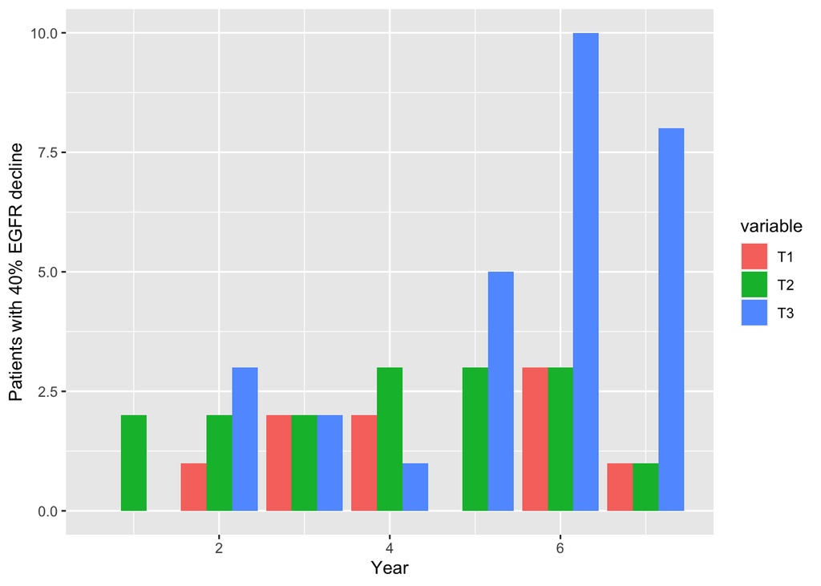

```r
Wide_data <- melt(df, id.vars = "year")
ggplot(Wide_data, aes(fill=variable, y=value, x=year)) +
  geom_bar(position="dodge", stat="identity")+labs(y="Patients with 40% EGFR decline", x="Year")
```

## 4.2 The percentage estimated (each year events with each tertile/total number of events multiply by 100). After percentage estimation, we estimated cumulative ESKD

```r
#Estimate cumulative for T1, T2, and T3
TalSample<-sum(df[2]+df[3]+df[4])
x<-df[-1]/TalSample*100
#print percentage
print(x)
```

```
##         T1       T2        T3
## 1 0.000000 3.703704  0.000000
## 2 1.851852 3.703704  5.555556
## 3 3.703704 3.703704  3.703704
## 4 3.703704 5.555556  1.851852
## 5 0.000000 5.555556  9.259259
## 6 5.555556 5.555556 18.518519
## 7 1.851852 1.851852 14.814815
```

```r
x<-cumsum(x)
dfnew<-cbind(df[1],x)
print(dfnew)
```

```
##   year        T1        T2        T3
## 1    1  0.000000  3.703704  0.000000
## 2    2  1.851852  7.407407  5.555556
## 3    3  5.555556 11.111111  9.259259
## 4    4  9.259259 16.666667 11.111111
## 5    5  9.259259 22.222222 20.370370
## 6    6 14.814815 27.777778 38.888889
## 7    7 16.666667 29.629630 53.703704
```

## 4.3 Cumulative ESKD events with 40% EGFR decline (in %)

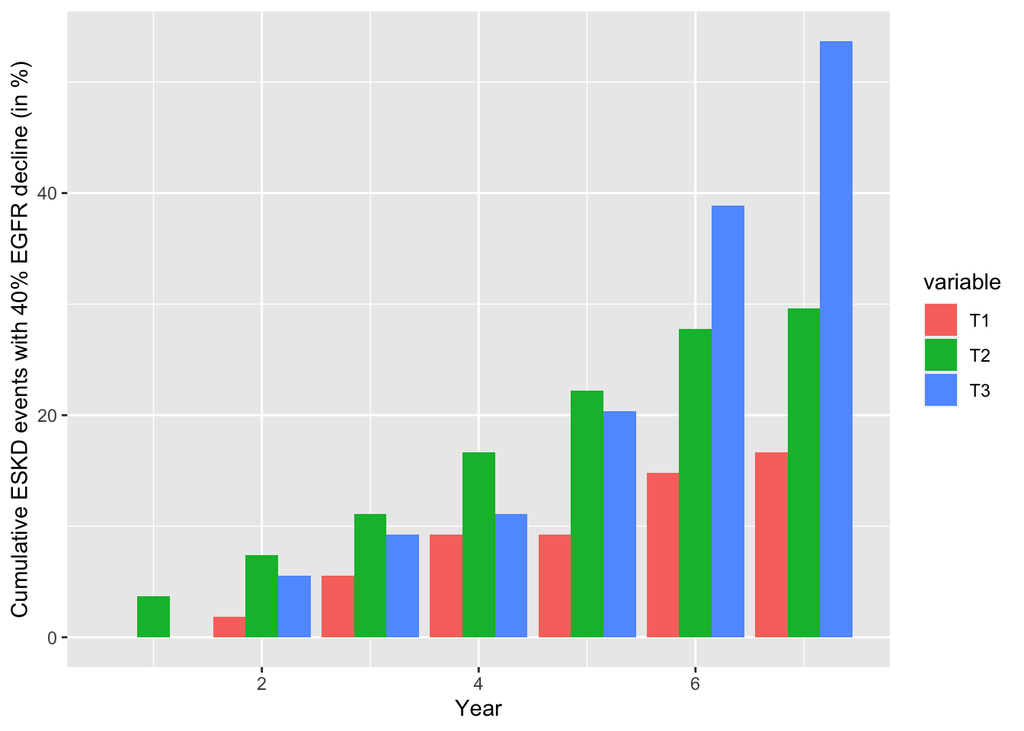

```r
Wide_data <- melt(dfnew, id.vars = "year")
ggplot(Wide_data, aes(fill=variable, y=value, x=year)) +
  geom_bar(position="dodge", stat="identity")+labs(y="Cumulative ESKD events with 40% EGFR decline (in %)", x="Year")
```

## 4.4 Fitting a line (method = “lm”) with ESKD risk wrt years for each tertile

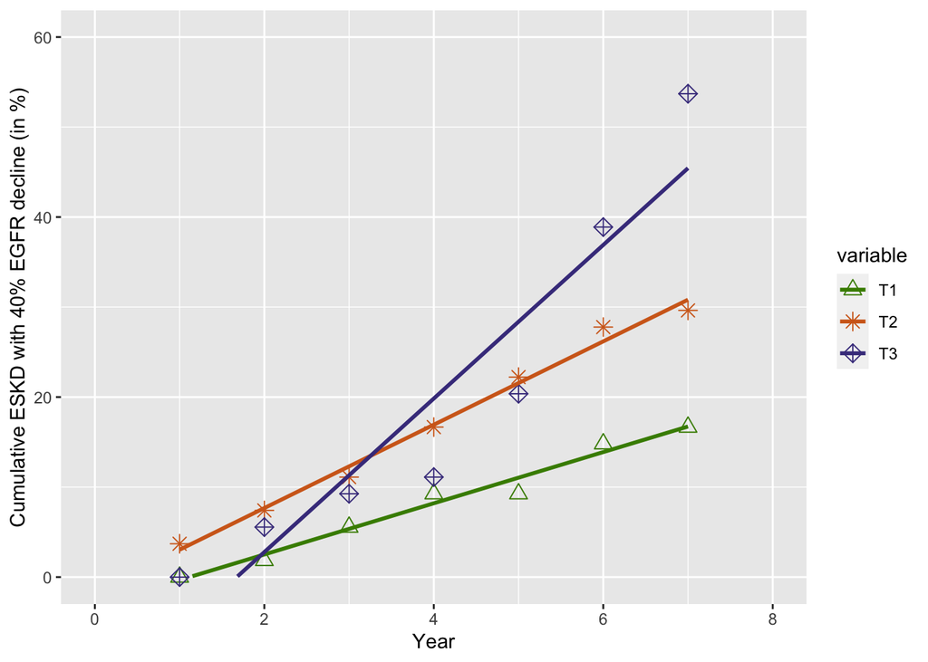

```r
ggplot(Wide_data, aes(x = year, y = value,shape = variable, colour = variable)) +geom_point(size=3)+
  geom_smooth( method = "lm", formula= "y~x", se=F)+scale_y_continuous(limits =c(0,60))+
  scale_x_continuous(limits =c(0,8))+scale_shape_manual(values = c(24, 8, 9)) +
  scale_colour_manual(values = c("chartreuse4", "chocolate", "slateblue4"))+labs(y="Cumulative ESKD with 40% EGFR decline (in %)", x="Year")
```

## 4.5 Fitting a line (method = “loess”) with ESKD risk wrt years for each tertile

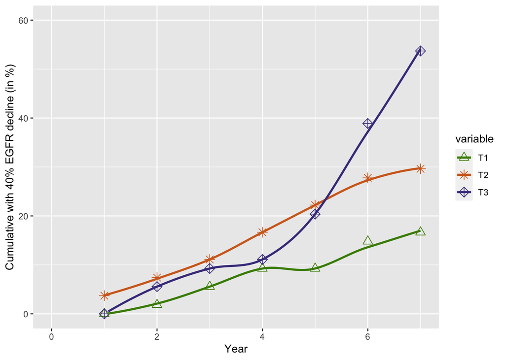

```r
ggplot(Wide_data, aes(x = year, y = value,shape = variable, colour = variable)) +geom_point(size=3)+
  geom_smooth( method = "loess", formula= "y~x", se=F)+scale_y_continuous(limits =c(0,60))+
  scale_x_continuous(limits =c(0,7))+scale_shape_manual(values = c(24, 8, 9)) +
  scale_colour_manual(values = c("chartreuse4", "chocolate", "slateblue4"))+labs(y="Cumulative with 40% EGFR decline (in %)", x="Year")
```

```r
model1<-glm(dfnew$year~dfnew$T1,data=dfnew)
model2<-glm(dfnew$year~dfnew$T2,data=dfnew)
model3<-glm(dfnew$year~dfnew$T3,data=dfnew)
```

# 5 Micro Group: 40% decline at each year

```r
#print(paste("year", "T1events", "T2events", "T3events"))

#make a dataframe to hold event count
df_micro <- data.frame(matrix(nrow=6, ncol = 4))
colnames(df_micro) <- c("year", "T1", "T2", "T3")

#select eGFR
EGFR<-rawdata%>%
   dplyr::select(egfr_cric_v5y1,egfr_cric_v7y2,egfr_cric_v9y3,egfr_cric_v11y4,egfr_cric_v13y5,egfr_cric_v15y6,egfr_cric_v17y7,egfr_cric_v19y8,egfr_cric_v21y9,egfr_cric_v23y10)
#loop over years and count events for each year
for (year in 1:6){
  #print(year)
  #calculate 40% decline at each year
  t1 <- EGFR[,year]
  t0 <- rawdata$egfr_cric_v3y0
  rawdata$outcome = ((t1-t0)/t0 < -.40)# | (t2==1)
  T1events <- sum(rawdata$outcome[T1pats & micropats], na.rm = TRUE)
  T2events <- sum(rawdata$outcome[T2pats & micropats], na.rm = TRUE)
  T3events <- sum(rawdata$outcome[T3pats & micropats], na.rm = TRUE)
  df_micro$year[year] <- year
  df_micro$T1[year] <- T1events
  df_micro$T2[year] <- T2events
  df_micro$T3[year] <- T3events
}
print(df_micro)
```

```
##   year T1 T2 T3
## 1    1  1  1  3
## 2    2  3  4  4
## 3    3  6  9 12
## 4    4  7  7 13
## 5    5  8  8 12
## 6    6  5  5 10
```

## 5.1 Estimate 40% decline bar graph with positive events

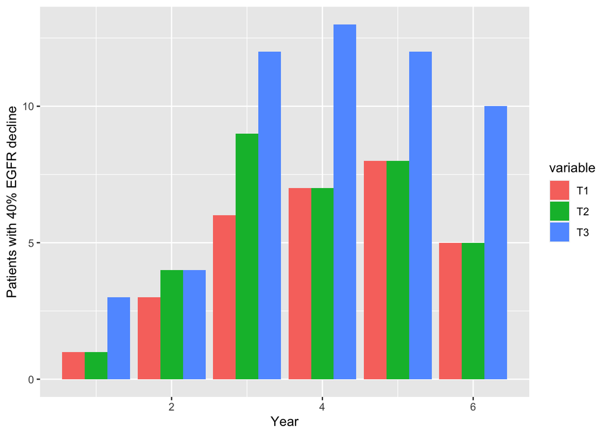

```r
Wide_data <- melt(df_micro, id.vars = "year")
ggplot(Wide_data, aes(fill=variable, y=value, x=year)) +
  geom_bar(position="dodge", stat="identity")+labs(y="Patients with 40% EGFR decline", x="Year")
```

## 5.2 The percentage estimated (each year events with each tertile/total number of events multiply by 100). After percentage estimation, we estimate cumulative ESKD

```r
#Estimate cumulative for T1, T2, and T3
TalSample<-sum(df_micro[2]+df_micro[3]+df_micro[4])
x<-df_micro[-1]/TalSample*100
#print percentage
print(x)
```

```
##          T1        T2        T3
## 1 0.8474576 0.8474576  2.542373
## 2 2.5423729 3.3898305  3.389831
## 3 5.0847458 7.6271186 10.169492
## 4 5.9322034 5.9322034 11.016949
## 5 6.7796610 6.7796610 10.169492
## 6 4.2372881 4.2372881  8.474576
```

```r
x<-cumsum(x)
df_micronew<-cbind(df_micro[1],x)
print(df_micronew)
```

```
##   year         T1         T2        T3
## 1    1  0.8474576  0.8474576  2.542373
## 2    2  3.3898305  4.2372881  5.932203
## 3    3  8.4745763 11.8644068 16.101695
## 4    4 14.4067797 17.7966102 27.118644
## 5    5 21.1864407 24.5762712 37.288136
## 6    6 25.4237288 28.8135593 45.762712
```

## 5.3 Cumulative ESKD events with 40% EGFR decline (in %)

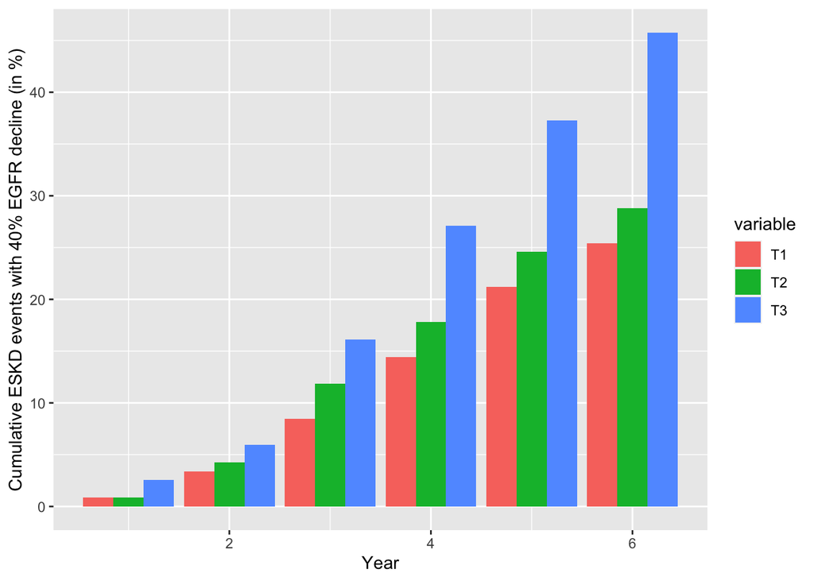

```r
Wide_data <- melt(df_micronew, id.vars = "year")
ggplot(Wide_data, aes(fill=variable, y=value, x=year)) +
  geom_bar(position="dodge", stat="identity")+labs(y="Cumulative ESKD events with 40% EGFR decline (in %)", x="Year")
```

## 5.4 Fitting a line (method = “lm”) with ESKD risk wrt years for each tertile

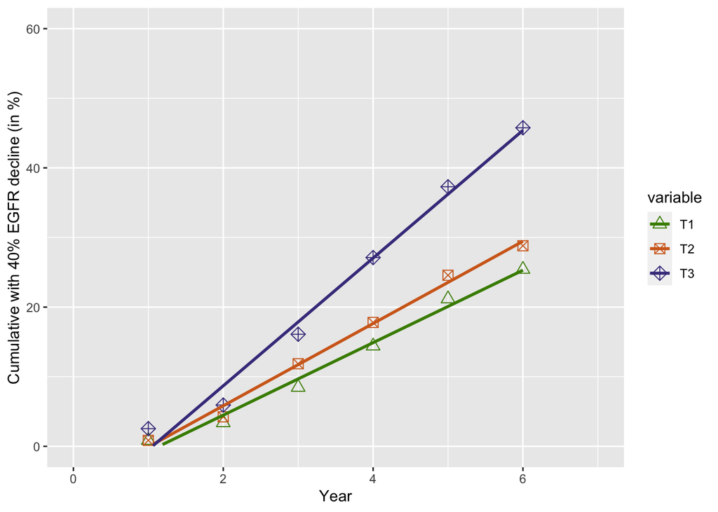

```r
ggplot(Wide_data, aes(x = year, y = value,shape = variable, colour = variable)) +geom_point(size=3)+
  geom_smooth( method = "lm", formula= "y~x", se=F)+scale_y_continuous(limits =c(0,60))+
  scale_x_continuous(limits =c(0,7))+scale_shape_manual(values = c(24, 7, 9)) +
  scale_colour_manual(values = c("chartreuse4", "chocolate", "slateblue4"))+labs(y="Cumulative with 40% EGFR decline (in %)", x="Year")
```

## 5.5 Fitting a line (method = “loess”) with ESKD risk wrt years for each tertile

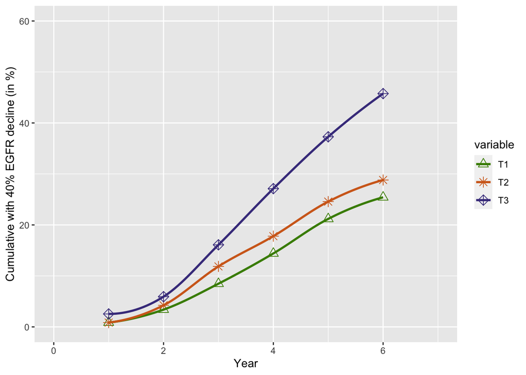

```r
ggplot(Wide_data, aes(x = year, y = value,shape = variable, colour = variable)) +geom_point(size=3)+
  geom_smooth( method = "loess", formula= "y~x", se=F)+scale_y_continuous(limits =c(0,60))+
  scale_x_continuous(limits =c(0,7))+scale_shape_manual(values = c(24, 8, 9)) +
  scale_colour_manual(values = c("chartreuse4", "chocolate", "slateblue4"))+labs(y="Cumulative with 40% EGFR decline (in %)", x="Year")
```

# 6 Normal and Micro Group: 40% eGFR decline at each year

```r
#print(paste("year", "T1events", "T2events", "T3events"))

#make a dataframe to hold event count
df <- data.frame(matrix(nrow=7, ncol = 4))
colnames(df) <- c("year", "T1", "T2", "T3")
#Count no. of false patients for each tertile
ptdf<-data.frame(matrix(nrow=7,ncol=4))
colnames(ptdf) <- c("year", "T1", "T2", "T3")
#select eGFR
EGFR<-rawdata%>%
   dplyr::select(egfr_cric_v5y1,egfr_cric_v7y2,egfr_cric_v9y3,egfr_cric_v11y4,egfr_cric_v13y5,egfr_cric_v15y6,egfr_cric_v17y7,egfr_cric_v19y8,egfr_cric_v21y9,egfr_cric_v23y10)
#loop over years and count events for each year
for (year in 1:7){
  #print(year)
  #calculate 40% decline at each year
  t1 <- EGFR[,year]
  t0 <- rawdata$egfr_cric_v3y0
  rawdata$outcome = ((t1-t0)/t0 < -.40)# | (t2==1)
  T1events <- sum(rawdata$outcome[T1pats & normopats | T1pats & micropats], na.rm = TRUE)
  T2events <- sum(rawdata$outcome[T2pats & normopats | T2pats & micropats], na.rm = TRUE)
  T3events <- sum(rawdata$outcome[T3pats & normopats | T3pats & micropats], na.rm = TRUE)

  df$year[year] <- year

  df$T1[year] <- T1events
  df$T2[year] <- T2events
  df$T3[year] <- T3events
}
print(df)
```

```
##   year T1 T2 T3
## 1    1  1  3  3
## 2    2  4  6  7
## 3    3  8 11 14
## 4    4  9 10 14
## 5    5  8 11 17
## 6    6  8  8 20
## 7    7 11  7 16
```

## 6.1 40% eGFR decline bar graph with positive events

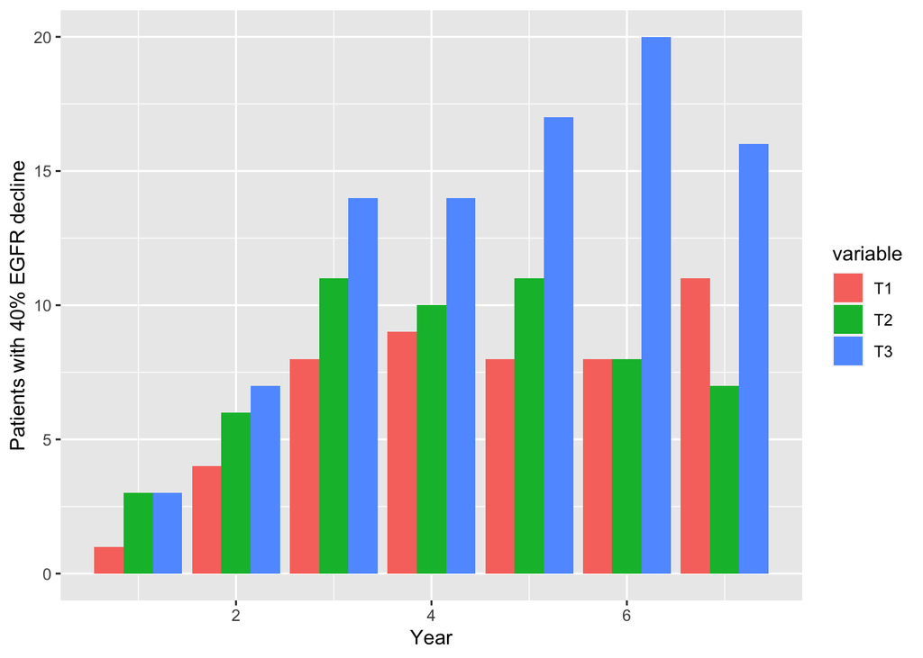

```r
Wide_data <- melt(df, id.vars = "year")
ggplot(Wide_data, aes(fill=variable, y=value, x=year)) +
  geom_bar(position="dodge", stat="identity")+labs(y="Patients with 40% EGFR decline", x="Year")
```

## 6.2 The percentage estimated (each year events with each tertile/total number of events multiply by 100). After percentage estimation, we estimated cumulative ESKD

```r
#Estimate cumulative for T1, T2, and T3
TalSample<-sum(df[2]+df[3]+df[4])
x<-df[-1]/TalSample*100
#print percentage
print(x)
```

```
##          T1       T2        T3
## 1 0.5102041 1.530612  1.530612
## 2 2.0408163 3.061224  3.571429
## 3 4.0816327 5.612245  7.142857
## 4 4.5918367 5.102041  7.142857
## 5 4.0816327 5.612245  8.673469
## 6 4.0816327 4.081633 10.204082
## 7 5.6122449 3.571429  8.163265
```

```r
x<-cumsum(x)
dfnew<-cbind(df[1],x)
print(dfnew)
```

```
##   year         T1        T2        T3
## 1    1  0.5102041  1.530612  1.530612
## 2    2  2.5510204  4.591837  5.102041
## 3    3  6.6326531 10.204082 12.244898
## 4    4 11.2244898 15.306122 19.387755
## 5    5 15.3061224 20.918367 28.061224
## 6    6 19.3877551 25.000000 38.265306
## 7    7 25.0000000 28.571429 46.428571
```

## 6.3 Cumulative ESKD events with 40% EGFR decline (in %)

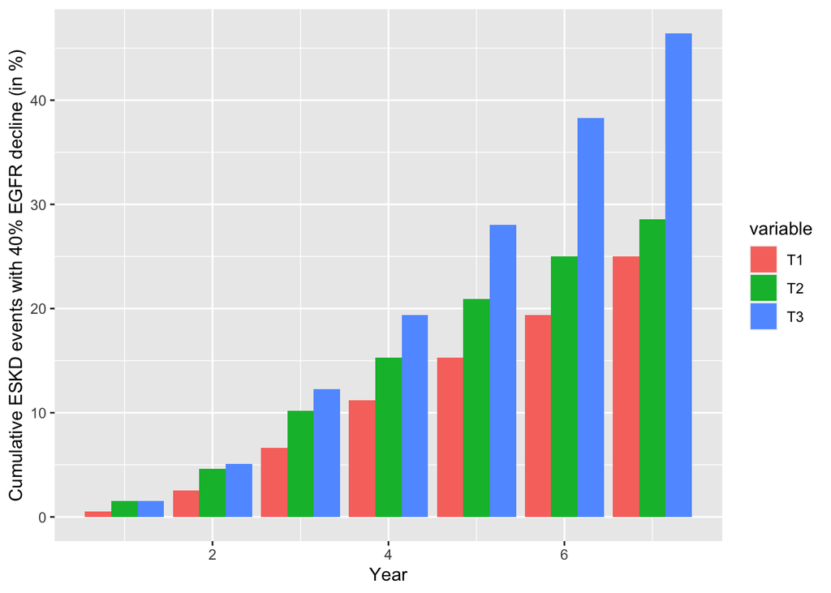

```r
Wide_data <- melt(dfnew, id.vars = "year")
ggplot(Wide_data, aes(fill=variable, y=value, x=year)) +
  geom_bar(position="dodge", stat="identity")+labs(y="Cumulative ESKD events with 40% EGFR decline (in %)", x="Year")
```

## 6.4 Fitting a line (method = “lm”) with ESKD risk wrt years for each tertile

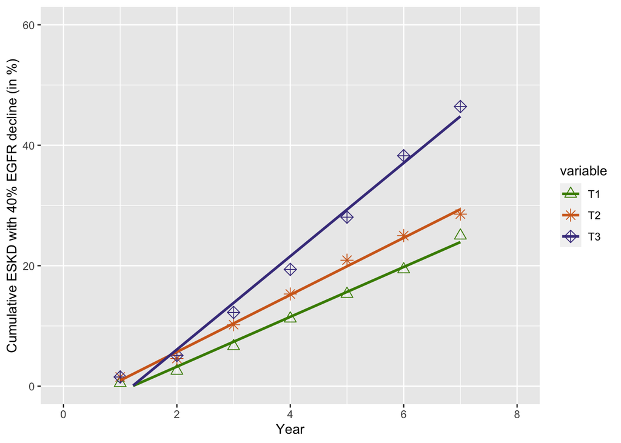

```r
ggplot(Wide_data, aes(x = year, y = value,shape = variable, colour = variable)) +geom_point(size=3)+
  geom_smooth( method = "lm", formula= "y~x", se=F)+scale_y_continuous(limits =c(0,60))+
  scale_x_continuous(limits =c(0,8))+scale_shape_manual(values = c(24, 8, 9)) +
  scale_colour_manual(values = c("chartreuse4", "chocolate", "slateblue4"))+labs(y="Cumulative ESKD with 40% EGFR decline (in %)", x="Year")
```

## 6.5 Fitting a line (method = “loess”) with ESKD risk wrt years for each tertile

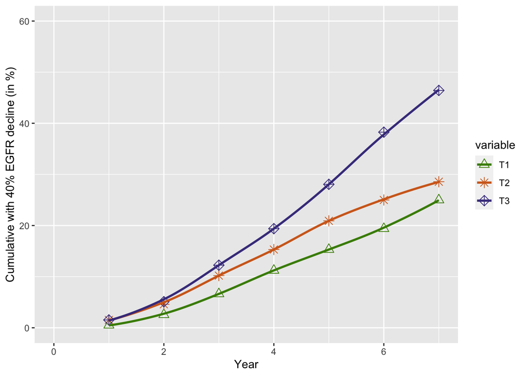

```r
ggplot(Wide_data, aes(x = year, y = value,shape = variable, colour = variable)) +geom_point(size=3)+
  geom_smooth( method = "loess", formula= "y~x", se=F)+scale_y_continuous(limits =c(0,60))+
  scale_x_continuous(limits =c(0,7))+scale_shape_manual(values = c(24, 8, 9)) +
  scale_colour_manual(values = c("chartreuse4", "chocolate", "slateblue4"))+labs(y="Cumulative with 40% EGFR decline (in %)", x="Year")
```

```r
model1<-glm(dfnew$year~dfnew$T1,data=dfnew)
model2<-glm(dfnew$year~dfnew$T2,data=dfnew)
model3<-glm(dfnew$year~dfnew$T3,data=dfnew)
```